# Case Study 4

Shubh Shah

2024-11-05

This case will be going over both the Boston data set and the German Credit data set

#### Boston Housing Data

The goal for the Boston Housing data set was the analyze and model the housing data set using CART and linear regression. Starting off, I had loaded the data from the MASS library splitting the data into 90% training and 10% testing. Below will show the code.

```r
boston <- data(Boston)
sample_index <- sample(nrow(Boston), nrow(Boston)*0.90)
train <- Boston[sample_index, ]
test <- Boston[-sample_index, ]
```

After splitting the dataset, I had visualized the regression tree model using the training data set predicting the target median home value (medv). Afterwards, I had visualized the regression tree using the ‘prp’ function, which had displayed the splits at each node.

```r
boston_rpart <- rpart(formula = medv ~., data = train)
boston_rpart
```

```
## n= 455
##
## node), split, n, deviance, yval
##       * denotes terminal node
##
##  1) root 455 38375.4200 22.41429
##    2) rm< 6.9715 391 15109.1100 19.80691
##      4) lstat>=14.405 159  3124.6170 14.83396
##        8) crim>=6.99237 68  1005.8190 11.81765 *
##        9) crim< 6.99237 91  1037.8170 17.08791 *
##      5) lstat< 14.405 232  5357.5570 23.21509
##       10) lstat>=4.91 215  3259.4500 22.50140
##         20) rm< 6.142 96   608.3896 20.48958 *
##         21) rm>=6.142 119  1949.0590 24.12437
##           42) lstat>=10.045 34   178.2800 21.20000 *
##           43) lstat< 10.045 85  1363.7070 25.29412 *
##       11) lstat< 4.91 17   603.6012 32.24118 *
##    3) rm>=6.9715 64  4368.2580 38.34375
##      6) rm< 7.437 36   951.8956 32.91111 *
##      7) rm>=7.437 28   987.8171 45.32857 *
```

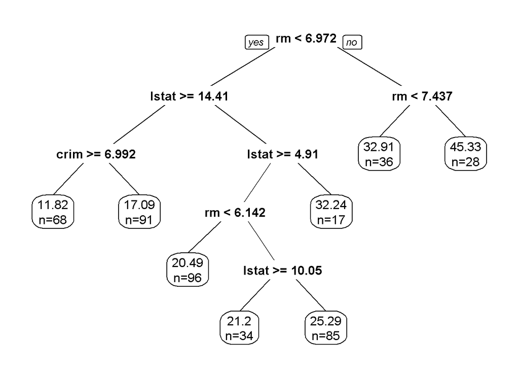

```r
prp(boston_rpart, digits = 4, extra = 1)
```

After visualization, I had then started to work on finding the in-sample and out-of-sample predictions. Below will be the in-sample-predictions. When running this model, I had got low values, before finalizing this project, I had received a MSE of 15.72. However, a low value would represent a better fit. But its important to understand overfitting

```r
# In Sample Prediction
boston_train_pred_tree = predict(boston_rpart)
mse.tree <- mean((boston_train_pred_tree - train$medv)^2)
print(mse.tree)
```

```
## [1] 14.80731
```

I had moved on to finding the out of sample predictions. I had found it by finding the averaged squared difference betweeen the predicted and actual values of medv in the test set. Its important that I find this as it would measure how it generalize on new, unforseen data. A higher out of sample MSE. Before submission, I had received a value of 29.98356. Since my out of sample is higher than my in sample, this can be an example of overfitting. However after running this model multiple times, it would seem that the in sample would be lower than out of sample at certain points.

```r
# Out of Sample Prediction
boston_test_pred_tree = predict(boston_rpart, test)
mpse.tree <- mean((boston_test_pred_tree - test$medv)^2)
print(mpse.tree)
```

```
## [1] 44.46558
```

```r
boston.reg = lm(medv~. -indus -age, data = train)

boston_train_pred_reg = predict(boston.reg, train)
mse.reg <- mean((boston_train_pred_reg - train$medv)^2)
print(mse.reg)
```

```
## [1] 20.42501
```

```r
boston_test_pred_reg = predict(boston.reg, test)
mpse.reg <- mean((boston_test_pred_reg - test$medv)^2)
print(mpse.reg)
```

```
## [1] 39.12402
```

#### German Credit Data

```r
library(dplyr)
library(ROCR)
credit_data <- read.csv(file = "https://xiaoruizhu.github.io/Data-Mining-R/lecture/data/credit_default.csv", header=T)
```

Before I had done the split, I had certain categorical data converted to factors and then had performed the split. This would be 80% training and 20% testing.

```r
credit_data<- rename(credit_data, default=default.payment.next.month)
# convert categorical data to factor
credit_data$SEX<- as.factor(credit_data$SEX)
credit_data$EDUCATION<- as.factor(credit_data$EDUCATION)
credit_data$MARRIAGE<- as.factor(credit_data$MARRIAGE)
index <- sample(nrow(credit_data),nrow(credit_data)*0.80)
credit_train = credit_data[index,]
credit_test = credit_data[-index,]
```

I had then built the classification tree on the training model. Its going to be confusing, so I will do my best to label everything properly. The credit_rpart0 would represent an rpart model with no specific matrix applied.

```r
credit_rpart0 <- rpart(formula = default ~ ., data = credit_train, method = "class")
credit_rpart0
```

```
## n= 9600
##
## node), split, n, loss, yval, (yprob)
##       * denotes terminal node
##
## 1) root 9600 2115 0 (0.7796875 0.2203125)
##   2) PAY_0< 1.5 8587 1421 0 (0.8345173 0.1654827) *
##   3) PAY_0>=1.5 1013  319 1 (0.3149062 0.6850938) *
```

The second one would represent a model with the assumption that the false negatives would cost 5 times of false positives. This would be from within the Classification Tree PDF. From my understanding, I believe that it assigns 5 for false negatives and 1 for false positives, I had used the lecture to help.

```r
credit_rpart <- rpart(formula = default ~ . , data = credit_train, method = "class", parms = list(loss=matrix(c(0,5,1,0), nrow = 2)))
credit_rpart
```

```
## n= 9600
##
## node), split, n, loss, yval, (yprob)
##       * denotes terminal node
##
## 1) root 9600 7485 1 (0.7796875 0.2203125)
##   2) PAY_0< 0.5 7454 5110 0 (0.8628924 0.1371076)
##     4) PAY_AMT3>=810.5 5477 3035 0 (0.8891729 0.1108271)
##       8) PAY_5< 1 5261 2705 0 (0.8971678 0.1028322) *
##       9) PAY_5>=1 216  150 1 (0.6944444 0.3055556) *
##     5) PAY_AMT3< 810.5 1977 1562 1 (0.7900860 0.2099140) *
##   3) PAY_0>=0.5 2146 1053 1 (0.4906803 0.5093197) *
```

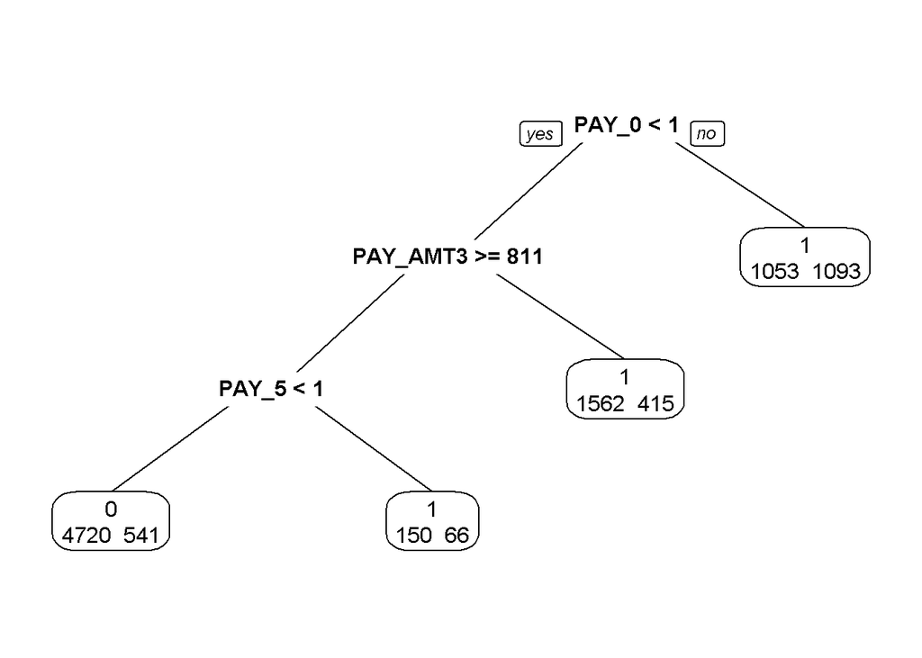

```r
prp(credit_rpart, extra = 1)
```

In Sample prediction. Predicted ‘default’ values on traing data

```r
pred0 <- predict(credit_rpart0, type="class")
table(credit_train$default, pred0, dnn = c("True", "Pred"))
```

```
##     Pred
## True    0    1
##    0 7166  319
##    1 1421  694
```

```r
credit_train.pred.tree1<- predict(credit_rpart, credit_train, type="class")
table(credit_train$default, credit_train.pred.tree1, dnn=c("Truth","Predicted"))
```

```
##      Predicted
## Truth    0    1
##     0 4720 2765
##     1  541 1574
```

Out of Sample

```r
credit_test.pred.tree1<-predict(credit_rpart, credit_test, type="class")
table(credit_test$default, credit_test.pred.tree1, dnn = c("Truth", "Predicted"))
```

```
##      Predicted
## Truth    0    1
##     0 1177  706
##     1  119  398
```

Missclassification

```r
cost <- function(r, phat){
  weight1 <- 5
  weight0 <- 1
  pcut <- weight0/(weight1+weight0)
  c1 <- (r==1)&(phat<pcut) #logical vector - true if actual 1 but predict 0
  c0 <-(r==0)&(phat>pcut) #logical vector - true if actual 0 but predict 1
  return(mean(weight1*c1+weight0*c0))
}

cost(credit_train$default, predict(credit_rpart, credit_train, type="prob"))
```

```
## [1] 0.6747396
```

Out of Sample Missclassification

```r
cost(credit_test$default, predict(credit_rpart, credit_test, type = "prob"))
```

```
## [1] 0.6633333
```

Logisitic Regression Model for Comparison

```r
#Fit logistic regression model
credit_glm <- glm(default~.,data = credit_train,family=binomial)
#Get binary prediction
credit_test_pred_glm <- predict(credit_glm, credit_test, type="response")
#Calculate cost using test set
cost(credit_test$default, credit_test_pred_glm)
```

```
## [1] 0.63375
```

AUC Calculation: the value of 0.7214 (when I had ran it) indicated that it can correctly identify defaults. I do beleive that there is room for improvement within this model itself. However, it is effective in finding high risk customers.

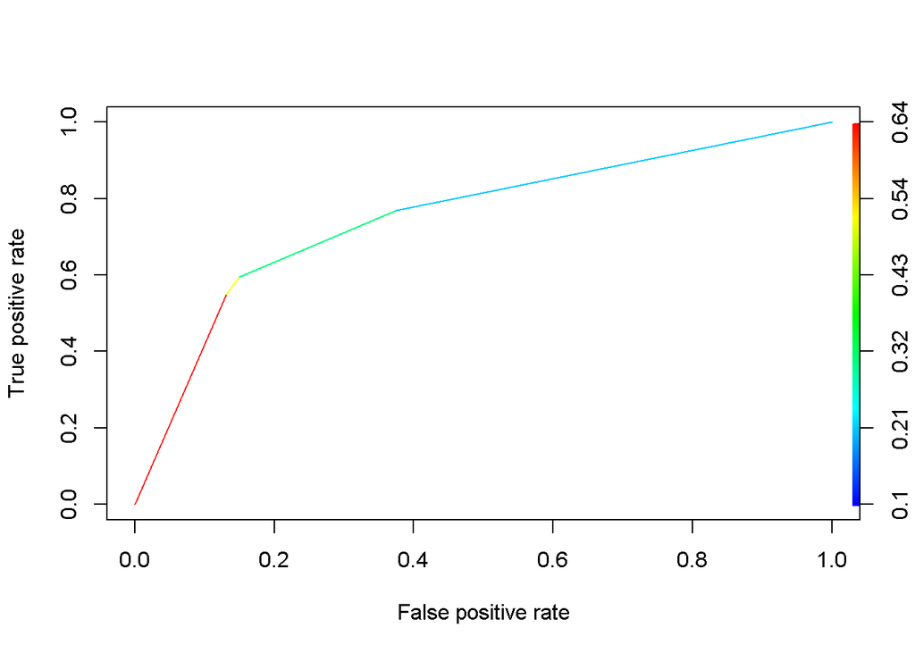

```r
credit_test_prob_rpart = predict(credit_rpart, credit_test, type="prob")

pred = prediction(credit_test_prob_rpart[,2], credit_test$default)
perf = performance(pred, "tpr", "fpr")
plot(perf, colorize=TRUE)
```

```r
slot(performance(pred, "auc"), "y.values")[[1]]
```

```
## [1] 0.7536027
```